# A6 - Event study analysis

A poor man’s shiny app

Andrew Dickinson

Winter 2021

> Due date: 24 February 2021

## Question

An event study can be described by the estimation of the model,
$$y_{it} = \alpha_i + \sum_{t~\ne~T-1}\beta_t~(T_{it}=1)+e_{it}~,$$
where $T_{it}=1$ captures the arrival of treatment (in period $T$). The sum is meant to imply that the omitted category is the period prior to the onset of treatment.

**Part 1.** Simulate a DGP in which treatment is imposed on a fraction of units in a panel. Adopting something like the DGP of A5 would be reasonable. Produce an event study figure the represents the effect of treatment on outcomes.

**Part 2:** Build into that DGP the potential for **(i)** non-parallel trends, **(ii)** parallel pre-treatment trends, with trends diverging in post treatment periods, **(iii)** an Ashenfelter dip, and **(iv)** a treatment that is anticiapted (in a way that has units “responding” before it arrives. (*There are more violations, obviously, but these are a good set to start with. Add others if you are in an area that you think has a particular challenge.*)

## DGP function

```r
es_sim = function(iter = 1, n_ind = 10, n_period = 11, event = 6, pre_treat = 5, post_treat = 5) {
  n_obs = n_period*n_ind
  ## Generate dgp
  dat_iter = tibble(
    ## iteration
    iter = iter,
    ## timing of treatment
    event = event,
    ## id variable
    id = rep(1:n_ind, len = n_obs),
    ## time variables: est_time limits the number of time interactions to function inputs
    time = rep(1:n_period, each = n_obs / n_period),
    est_time = case_when(
          time < event - pre_treat ~ -pre_treat,
          time > event + post_treat ~ post_treat,
          TRUE ~ time - event
        ),
    ## Var that turns on after treatment
    post = ifelse(time >= event, 1, 0),
    lag1_post = ifelse(time == (event - 1) , 1, 0),
    lag2_post = ifelse(time == (event - 2) , 1, 0),
    lag3_post = ifelse(time == (event - 3), 1, 0),
    ## Random assignment of treatment
    treat = rep(0:1, length = n_obs),
    ## Grouping into pre-post treat-control groups
    group = case_when(
          treat == 1 & time >= event ~ 1,
          treat == 1 & time <event ~ 2,
          treat == 0 & time >= event ~ 3,
          TRUE ~ 4
        ),
    ## Generate outcome variables
    ## parallel trends
    para = 2 + 2*(treat == 1) + (0.2*time) + 1.5*(treat == 1)*(post == 1) + rnorm(n_obs),
    ## not parallel trends
    npara = para - (0.3*time)*(treat == 0),
    ## divergent trends following treatment
    div = para - 1.5*(treat == 1)*(post == 1) + 1.5*(treat == 1)*(post == 1)*(time / event)^1.7,
    ## ashenfelter dip - selection into treatment
    ash = para - 0.75*(treat == 1)*(lag1_post == 1) - .5*(treat == 1)*(lag2_post == 1)
               - 0.25*(treat == 1)*(lag3_post == 1),
    ## anticipation of treatment
    ant = para + 1*(treat == 1)*(lag1_post == 1) + 0.5*(treat == 1)*(lag2_post == 1)
               + 0.25*(treat == 1)*(lag3_post == 1)
  ) %>% panel(panel.id = ~id + time) %>%
    arrange(id, time)

  ## Estimate the four models

   m_para = feols(data = dat_iter, para ~ i(treat, est_time, -1) | id + time) %>% tidy(conf.int = T) %>%
    mutate(time = readr::parse_number(as.character(term))) %>%
    select(time, term, estimate, p.value, conf.low, conf.high) %>%
    mutate(group = "Parallel trends",
           iter_group = paste0("Parallel trends", iter)) %>%
    arrange(time)

  m_npara = feols(data = dat_iter, npara ~ i(treat, est_time, -1) | id + time) %>% tidy(conf.int = T) %>%
    mutate(time = readr::parse_number(as.character(term))) %>%
    select(time, term, estimate, p.value, conf.low, conf.high) %>%
    mutate(group = "Not parallel trends",
           iter_group = paste0("Not parallel trends", iter)) %>%
    arrange(time)

  m_div = feols(data = dat_iter, div ~ i(treat, est_time, -1) | id + time) %>% tidy(conf.int = T) %>%
    mutate(time = readr::parse_number(as.character(term))) %>%
    select(time, term, estimate, p.value, conf.low, conf.high) %>%
    mutate(group = "Divergent post treatment trends",
           iter_group = paste0("Divergent post treatment trends", iter)) %>%
    arrange(time)

  m_ash = feols(data = dat_iter, ash ~ i(treat, est_time, -1) | id + time) %>% tidy(conf.int = T) %>%
    mutate(time = readr::parse_number(as.character(term))) %>%
    select(time, term, estimate, p.value, conf.low, conf.high) %>%
    mutate(group = "Ashenfelter dip",
           iter_group = paste0("Ashenfelter dip", iter)) %>%
    arrange(time)

  m_ant = feols(data = dat_iter, ant ~ i(treat, est_time, -1) | id + time) %>% tidy(conf.int = T) %>%
    mutate(time = readr::parse_number(as.character(term))) %>%
    select(time, term, estimate, p.value, conf.low, conf.high) %>%
    mutate(group = "Anticipation of treatment",
           iter_group = paste0("Anticipation of treatment", iter)) %>%
    arrange(time)

  ret = rbind(m_para,m_npara,m_div,m_ash,m_ant)

  return(ret)
}
```

## Visualization function

```r
es_vis = function(n_ind = 30, n_period = 11, event = 6, pre_treat = 5,
                  post_treat = 5){

  sim_list = map(1, es_sim, n_ind = n_ind, n_period = n_period,
                event = event, pre_treat = pre_treat, post_treat = post_treat)

  sim_df <- bind_rows(sim_list)

  g0 = ggplot(data = sim_df, aes(x = time, y = estimate)) +
    geom_point(size = 0.5, alpha = 1) +
    geom_point(aes(x = -1, y = 0), size = 1, shape = 1) +
    geom_linerange(aes(ymin = conf.low, ymax = conf.high),
                   position = position_dodge(width = 0.5), alpha = 0.5, color = grey_mid) +
    geom_point(aes(y = conf.low, color = factor(zero)), size = 1.5, color = grey_mid, alpha= 0.75, shape = 95) +
    geom_point(aes(y = conf.high, color = factor(zero)), size = 1.5, color = grey_mid, alpha= 0.75, shape = 95) +
    geom_hline(yintercept = 1.5, linetype = "dashed", color = "red", alpha = 0.5, size = 0.1) +
    ylim(-3, 5) +
    scale_x_continuous(breaks = seq(-pre_treat, post_treat, 1)) +
    scale_y_continuous(breaks = seq(-2,5,2)) +
    geom_hline(yintercept = c(-3,-2,-1,0,1,2,3,4,5), size = 0.05, alpha = 0.5) +
    geom_hline(yintercept = 0, size = 0.1, alpha = 1) +
    geom_vline(xintercept = -0.5, linetype = "dashed", size = 0.25, color= grey_mid) +
    theme_A6 +
    facet_wrap(~group, nrow = 5)

return(g0)
}
```

## Simulation (iter = 1)

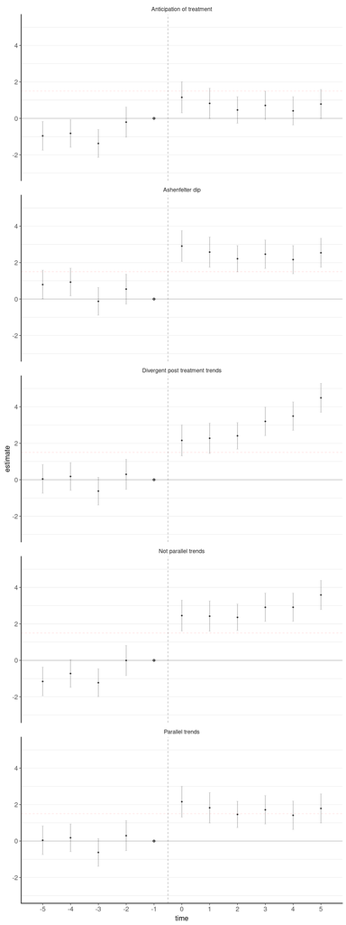

```r
es_vis(n_ind = 50, n_period = 11, event = 6, pre_treat = 5,post_treat = 5)
```

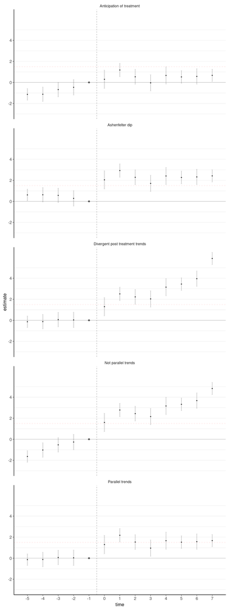

```r
es_vis(n_ind = 50, n_period = 20, event = 8, pre_treat = 5,post_treat = 7)
```

```r
es_vis_iter = function(iter = 1, n_ind = 30, n_period = 11, event = 6, pre_treat = 5,
                  post_treat = 5){

  sim_list = map(1:iter, es_sim, n_ind = n_ind, n_period = n_period,
                event = event, pre_treat = pre_treat, post_treat = post_treat)

sim_df <- bind_rows(sim_list)

g0 = ggplot(data = sim_df, aes(x = time, y = estimate)) +
  # geom_point(size = 0.25, alpha = 0.5) +
  geom_point(aes(x = -1, y = 0), size = 1, shape = 1) +
  geom_linerange(aes(ymin = conf.low, ymax = conf.high),
                 position = position_dodge(width = 0.5), alpha = 0.01, size = 1.5, color = grey_dark) +
  geom_hline(yintercept = 1.5, linetype = "dashed", color = "red", alpha = 0.05, size = 0.1) +
  geom_hline(yintercept = 1.5, linetype = "dashed", color = "red", alpha = 0.5, size = 0.1) +
  lims(x= c(-pre_treat, post_treat), y = c(-3,5)) +
  scale_x_continuous(breaks = seq(-pre_treat, post_treat, 1)) +
  geom_hline(yintercept = c(-3,-2,-1,0,1,2,3,4,5), size = 0.05, alpha = 0.5) +
  geom_hline(yintercept = 0, size = 0.1, alpha = 1) +
  geom_vline(xintercept = -0.5, linetype = "dashed", size = 0.25, color= grey_mid) +
  theme_A6 +
  facet_wrap(~group, nrow = 5)

return(g0)
}
```

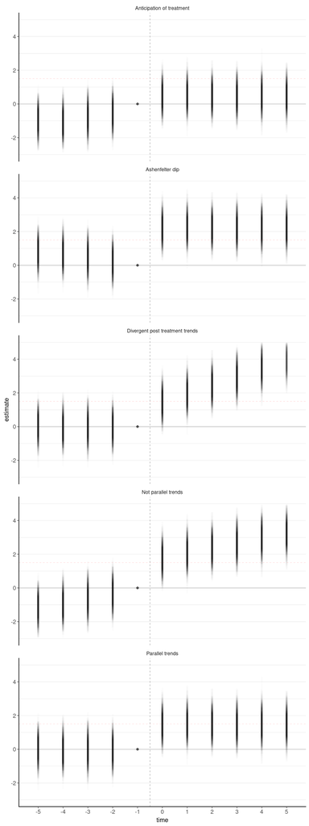

```r
es_vis_iter(iter = 200, n_ind = 40)
```